# ADP2

# 1 Preparations (준비작업)

## 1.1 Libraries

```r
library(data.table)
library(tidyverse)
library(caret)
library(recipes)
library(GGally)
library(janitor)
library(lubridate)
library(ggmosaic)
library(pROC)
#devtools::install_version("ggmosaic", version = "0.2.0")
#devtools::install_version("pROC", version = "1.16.2")
#devtools::install_version("factoextra", version = "1.0.7")
theme_set(theme_bw())
```

## 1.2 Data load

데이콘에서 진행했던 신용카드 사용자 연체 예측 ai 경진대회 데이터입니다. 원 데이터는 다중 분류 문제이지만, 먼저 이진 분류 문제로 바꿔서 진행해보겠습니다.

데이터 출처 https://www.dacon.io/competitions/official/235713/talkboard/402821/

```r
file_path <- "./data/credit_card"
files <- list.files(file_path)
files
```

```
## [1] "train.csv"
```

```r
dat <- fread(file.path(file_path, "train.csv"))
dat %>% select(credit) %>% table()
```

```
## .
##     0     1     2
##  3222  6267 16968
```

```r
dat %>%
    mutate(credit = replace(credit, credit == 0, 1),
           credit = replace(credit, credit == 1, 0),
           credit = replace(credit, credit == 2, 1)) %>%
    select(credit) %>% table()
```

```
## .
##     0     1
##  9489 16968
```

```r
dat <- dat %>% # 이진 분류 문제로 변경
    mutate(credit = replace(credit, credit == 0, 1),
           credit = replace(credit, credit == 1, 0),
           credit = replace(credit, credit == 2, 1))

dat$credit <- factor(dat$credit, labels = c("Good", "Bad"))
```

# 2 Data description

- index
- gender: 성별
- car: 차량 소유 여부
- reality: 부동산 소유 여부
- child_num: 자녀 수
- income_total: 연간 소득
- income_type: 소득 분류 [‘Commercial associate’, ‘Working’, ‘State servant’, ‘Pensioner’, ‘Student’]
- edu_type: 교육 수준 [‘Higher education’ ,‘Secondary / secondary special’, ‘Incomplete higher’, ‘Lower secondary’, ‘Academic degree’]
- family_type: 결혼 여부 [‘Married’, ‘Civil marriage’, ‘Separated’, ‘Single / not married’, ‘Widow’]
- house_type: 생활 방식 [‘Municipal apartment’, ‘House / apartment’, ‘With parents’, ‘Co-op apartment’, ‘Rented apartment’, ‘Office apartment’]
- DAYS_BIRTH: 출생일, 데이터 수집 당시 (0)부터 역으로 셈, 즉, -1은 데이터 수집일 하루 전에 태어났음을 의미
- DAYS_EMPLOYED: 업무 시작일, 데이터 수집 당시 (0)부터 역으로 셈, 즉, -1은 데이터 수집일 하루 전부터 일을 시작함을 의미. 양수 값은 고용되지 않은 상태를 의미함
- FLAG_MOBIL: 핸드폰 소유 여부
- work_phone: 업무용 전화 소유 여부
- phone: 전화 소유 여부
- email: 이메일 소유 여부
- occyp_type: 직업 유형
- family_size: 가족 규모
- begin_month: 신용카드 발급 월, 데이터 수집 당시 (0)부터 역으로 셈, 즉, -1은 데이터 수집일 한 달 전에 신용카드를 발급함을 의미

```r
dat %>% head()
```

```
##    index gender car reality child_num income_total          income_type
## 1:     0      F   N       N         0       202500 Commercial associate
## 2:     1      F   N       Y         1       247500 Commercial associate
## 3:     2      M   Y       Y         0       450000              Working
## 4:     3      F   N       Y         0       202500 Commercial associate
## 5:     4      F   Y       Y         0       157500        State servant
## 6:     5      F   N       Y         2       270000              Working
##                         edu_type    family_type          house_type DAYS_BIRTH
## 1:              Higher education        Married Municipal apartment     -13899
## 2: Secondary / secondary special Civil marriage   House / apartment     -11380
## 3:              Higher education        Married   House / apartment     -19087
## 4: Secondary / secondary special        Married   House / apartment     -15088
## 5:              Higher education        Married   House / apartment     -15037
## 6: Secondary / secondary special        Married   House / apartment     -13413
##    DAYS_EMPLOYED FLAG_MOBIL work_phone phone email            occyp_type
## 1:         -4709          1          0     0     0
## 2:         -1540          1          0     0     1              Laborers
## 3:         -4434          1          0     1     0              Managers
## 4:         -2092          1          0     1     0           Sales staff
## 5:         -2105          1          0     0     0              Managers
## 6:         -4996          1          0     0     1 High skill tech staff
##    family_size begin_month credit
## 1:           2          -6   Good
## 2:           3          -5   Good
## 3:           2         -22    Bad
## 4:           2         -37   Good
## 5:           2         -26    Bad
## 6:           4         -18   Good
```

```r
dat <- dat %>%
    janitor::clean_names() # 한글일 때는 주의 필요

dat %>% glimpse()
```

```
## Rows: 26,457
## Columns: 20
## $ index         <int> 0, 1, 2, 3, 4, 5, 6, 7, 8, 9, 10, 11, 12, 13, 14, 15, 16~
## $ gender        <chr> "F", "F", "M", "F", "F", "F", "F", "M", "M", "F", "F", "~
## $ car           <chr> "N", "N", "Y", "N", "Y", "N", "N", "N", "Y", "N", "N", "~
## $ reality       <chr> "N", "Y", "Y", "Y", "Y", "Y", "N", "Y", "Y", "Y", "Y", "~
## $ child_num     <int> 0, 1, 0, 0, 0, 2, 0, 0, 1, 0, 0, 1, 1, 0, 0, 2, 0, 0, 0,~
## $ income_total  <dbl> 202500, 247500, 450000, 202500, 157500, 270000, 315000, ~
## $ income_type   <chr> "Commercial associate", "Commercial associate", "Working~
## $ edu_type      <chr> "Higher education", "Secondary / secondary special", "Hi~
## $ family_type   <chr> "Married", "Civil marriage", "Married", "Married", "Marr~
## $ house_type    <chr> "Municipal apartment", "House / apartment", "House / apa~
## $ days_birth    <int> -13899, -11380, -19087, -15088, -15037, -13413, -17570, ~
## $ days_employed <int> -4709, -1540, -4434, -2092, -2105, -4996, -1978, -5420, ~
## $ flag_mobil    <int> 1, 1, 1, 1, 1, 1, 1, 1, 1, 1, 1, 1, 1, 1, 1, 1, 1, 1, 1,~
## $ work_phone    <int> 0, 0, 0, 0, 0, 0, 0, 0, 0, 0, 1, 0, 0, 0, 0, 0, 0, 0, 0,~
## $ phone         <int> 0, 0, 1, 1, 0, 0, 0, 0, 0, 0, 1, 0, 0, 1, 1, 1, 1, 0, 0,~
## $ email         <int> 0, 1, 0, 0, 0, 1, 1, 1, 1, 0, 1, 0, 0, 0, 0, 0, 0, 1, 0,~
## $ occyp_type    <chr> "", "Laborers", "Managers", "Sales staff", "Managers", "~
## $ family_size   <dbl> 2, 3, 2, 2, 2, 4, 1, 2, 3, 2, 1, 3, 3, 2, 1, 4, 2, 2, 2,~
## $ begin_month   <dbl> -6, -5, -22, -37, -26, -18, -41, -53, -38, -5, -40, -51,~
## $ credit        <fct> Good, Good, Bad, Good, Bad, Good, Bad, Good, Bad, Bad, B~
```

# 3 EDA(탐색적 자료분석)

## 3.1 변수 속성 변환

```r
dat %>%
    mutate_if(is.character, as.factor) %>%
    mutate_at(vars('flag_mobil', 'work_phone', 'phone', 'email', 'occyp_type', 'credit'), .funs = as.factor) %>%
    glimpse()
```

```
## Rows: 26,457
## Columns: 20
## $ index         <int> 0, 1, 2, 3, 4, 5, 6, 7, 8, 9, 10, 11, 12, 13, 14, 15, 16~
## $ gender        <fct> F, F, M, F, F, F, F, M, M, F, F, M, F, F, F, M, M, M, F,~
## $ car           <fct> N, N, Y, N, Y, N, N, N, Y, N, N, Y, Y, N, N, Y, N, N, N,~
## $ reality       <fct> N, Y, Y, Y, Y, Y, N, Y, Y, Y, Y, Y, Y, N, Y, Y, Y, N, Y,~
## $ child_num     <int> 0, 1, 0, 0, 0, 2, 0, 0, 1, 0, 0, 1, 1, 0, 0, 2, 0, 0, 0,~
## $ income_total  <dbl> 202500, 247500, 450000, 202500, 157500, 270000, 315000, ~
## $ income_type   <fct> Commercial associate, Commercial associate, Working, Com~
## $ edu_type      <fct> Higher education, Secondary / secondary special, Higher ~
## $ family_type   <fct> Married, Civil marriage, Married, Married, Married, Marr~
## $ house_type    <fct> Municipal apartment, House / apartment, House / apartmen~
## $ days_birth    <int> -13899, -11380, -19087, -15088, -15037, -13413, -17570, ~
## $ days_employed <int> -4709, -1540, -4434, -2092, -2105, -4996, -1978, -5420, ~
## $ flag_mobil    <fct> 1, 1, 1, 1, 1, 1, 1, 1, 1, 1, 1, 1, 1, 1, 1, 1, 1, 1, 1,~
## $ work_phone    <fct> 0, 0, 0, 0, 0, 0, 0, 0, 0, 0, 1, 0, 0, 0, 0, 0, 0, 0, 0,~
## $ phone         <fct> 0, 0, 1, 1, 0, 0, 0, 0, 0, 0, 1, 0, 0, 1, 1, 1, 1, 0, 0,~
## $ email         <fct> 0, 1, 0, 0, 0, 1, 1, 1, 1, 0, 1, 0, 0, 0, 0, 0, 0, 1, 0,~
## $ occyp_type    <fct> , Laborers, Managers, Sales staff, Managers, High skill ~
## $ family_size   <dbl> 2, 3, 2, 2, 2, 4, 1, 2, 3, 2, 1, 3, 3, 2, 1, 4, 2, 2, 2,~
## $ begin_month   <dbl> -6, -5, -22, -37, -26, -18, -41, -53, -38, -5, -40, -51,~
## $ credit        <fct> Good, Good, Bad, Good, Bad, Good, Bad, Good, Bad, Bad, B~
```

```r
dat <- dat %>%
    mutate_if(is.character, as.factor) %>%
    mutate_at(vars('flag_mobil', 'work_phone', 'phone', 'email', 'occyp_type', 'credit'), .funs = as.factor)
```

## 3.2 데이터 요약통계량

- 결측치 및 이상치 확인
- 변수별 요약 통계량 확인

```r
dat %>% summary()
```

```
##      index       gender    car       reality     child_num
##  Min.   :    0   F:17697   N:16410   N: 8627   Min.   : 0.0000
##  1st Qu.: 6614   M: 8760   Y:10047   Y:17830   1st Qu.: 0.0000
##  Median :13228                                 Median : 0.0000
##  Mean   :13228                                 Mean   : 0.4287
##  3rd Qu.:19842                                 3rd Qu.: 1.0000
##  Max.   :26456                                 Max.   :19.0000
##
##   income_total                   income_type
##  Min.   :  27000   Commercial associate: 6202
##  1st Qu.: 121500   Pensioner           : 4449
##  Median : 157500   State servant       : 2154
##  Mean   : 187307   Student             :    7
##  3rd Qu.: 225000   Working             :13645
##  Max.   :1575000
##
##                           edu_type                   family_type
##  Academic degree              :   23   Civil marriage      : 2123
##  Higher education             : 7162   Married             :18196
##  Incomplete higher            : 1020   Separated           : 1539
##  Lower secondary              :  257   Single / not married: 3496
##  Secondary / secondary special:17995   Widow               : 1103
##
##
##                house_type      days_birth     days_employed    flag_mobil
##  Co-op apartment    :  110   Min.   :-25152   Min.   :-15713   1:26457
##  House / apartment  :23653   1st Qu.:-19431   1st Qu.: -3153
##  Municipal apartment:  818   Median :-15547   Median : -1539
##  Office apartment   :  190   Mean   :-15958   Mean   : 59069
##  Rented apartment   :  429   3rd Qu.:-12446   3rd Qu.:  -407
##  With parents       : 1257   Max.   : -7705   Max.   :365243
##
##  work_phone phone     email           occyp_type    family_size
##  0:20511    0:18672   0:24042              :8171   Min.   : 1.000
##  1: 5946    1: 7785   1: 2415   Laborers   :4512   1st Qu.: 2.000
##                                 Core staff :2646   Median : 2.000
##                                 Sales staff:2539   Mean   : 2.197
##                                 Managers   :2167   3rd Qu.: 3.000
##                                 Drivers    :1575   Max.   :20.000
##                                 (Other)    :4847
##   begin_month      credit
##  Min.   :-60.00   Good: 9489
##  1st Qu.:-39.00   Bad :16968
##  Median :-24.00
##  Mean   :-26.12
##  3rd Qu.:-12.00
##  Max.   :  0.00
##
```

# 4 visualization

- 반응변수 vs 설명변수 상관계수 확인
- 설명변수 vs 설명변수 상관계수 확인
- 변수별 분포 확인(연속형 변수의 분포의 치우침, 범주형 변수의 class 불균형 확인)
- 범주형 설명변수와 반응변수 boxplot 그리기
- Package : **GGally**
- 문제 : 시각화 및 EDA

## 4.1 income_type : 소득 분류

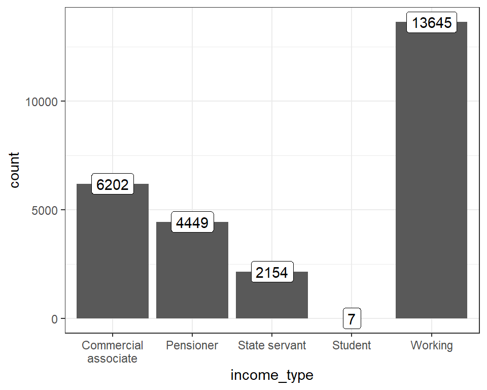

```r
ymd_rec <- dat %>%
    recipe(credit~.) %>%
    step_mutate(
              days_birth = days_birth + 25152, # 출생일
              days_employed = days_employed + 15713, # 업무 시작일
              begin_month = begin_month + 60) %>%
    step_mutate(
              year_birth = round(days_birth/365),
              month_birth = round(days_birth/30),
              year_employed = round(days_employed/365),
              month_employed = round(days_employed/30),
              begin_year = begin_month/12) %>%
    prep() %>%
    juice()


ymd_rec %>%
  ggplot(aes(x = income_type)) + geom_bar() +
  aes(stringr::str_wrap(income_type, 15)) +
  xlab('income_type')+
  geom_label(stat = 'count', aes(label = ..count..))
```

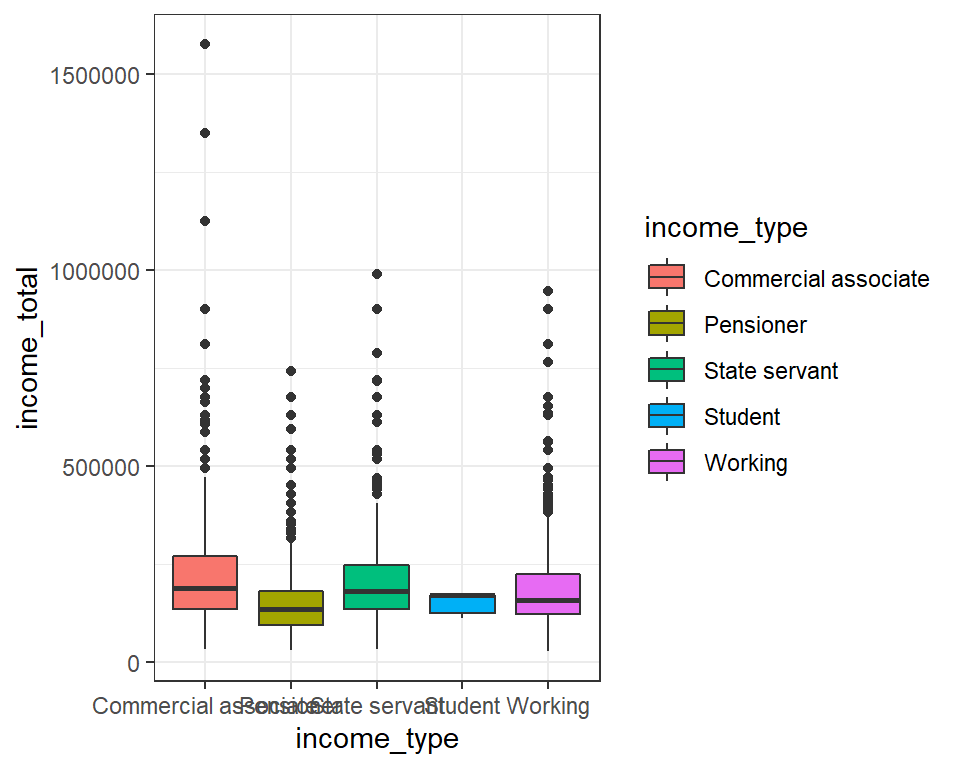

```r
ymd_rec %>%
  ggplot(aes(x = income_type, y = income_total)) +
  geom_boxplot(aes(fill = income_type))
```

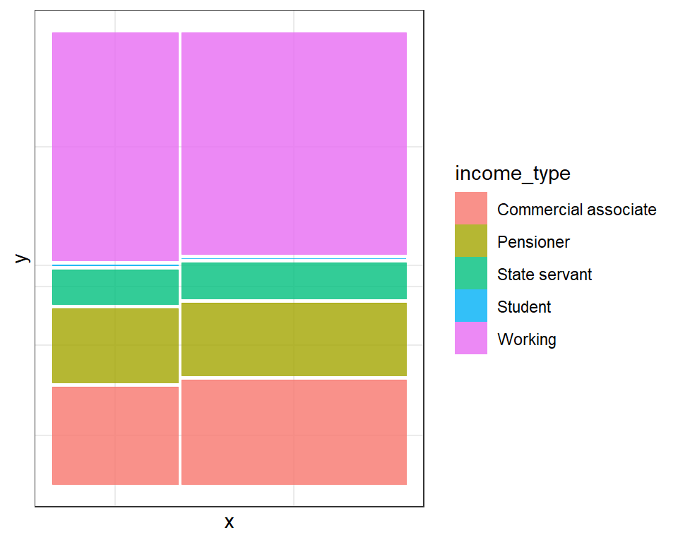

```r
ymd_rec %>%
    filter(!is.na(income_type), !is.na(credit)) %>%
    ggplot()+
    geom_mosaic(aes(x = product(income_type, credit), fill = income_type))
```

## 4.2 house_type : 생활 방식

co-op apartment(주택 협동조합), house apartment, municipal apartment(공공 주택), office apartment(회사), rented apartment(임대 주택), with parents

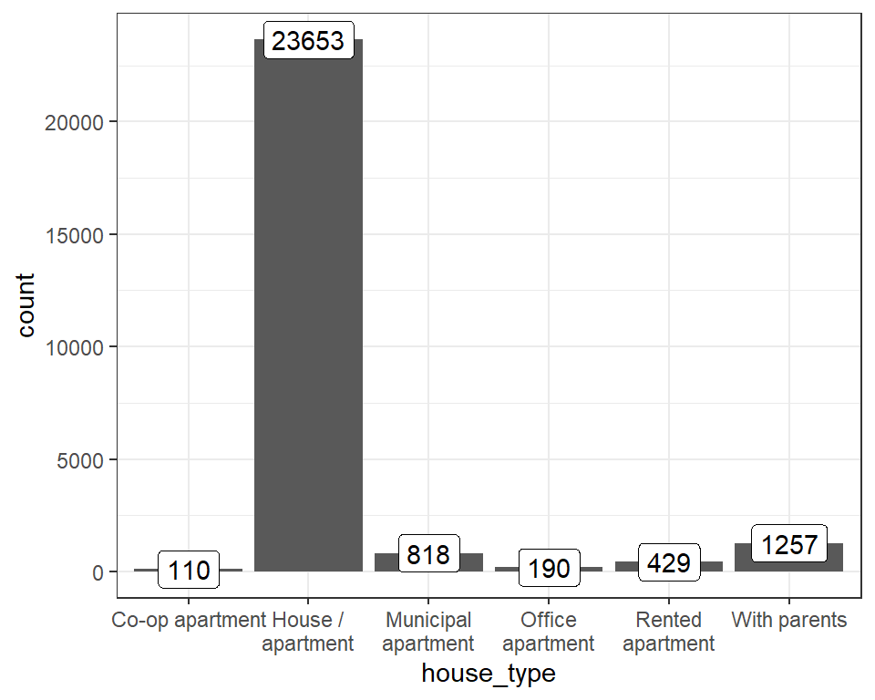

```r
ymd_rec %>%
  ggplot(aes(x = house_type)) + geom_bar() +
  aes(stringr::str_wrap(house_type, 15)) +
  xlab('house_type')+
  geom_label(stat = 'count', aes(label = ..count..))
```

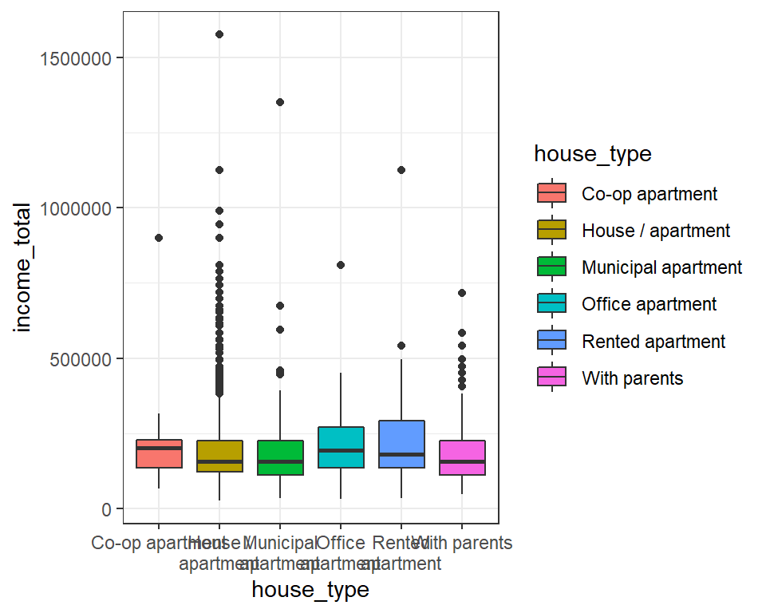

```r
ymd_rec %>%
  ggplot(aes(x = house_type, y = income_total)) +
  aes(stringr::str_wrap(house_type, 15)) +
  xlab('house_type')+
  geom_boxplot(aes(fill = house_type))
```

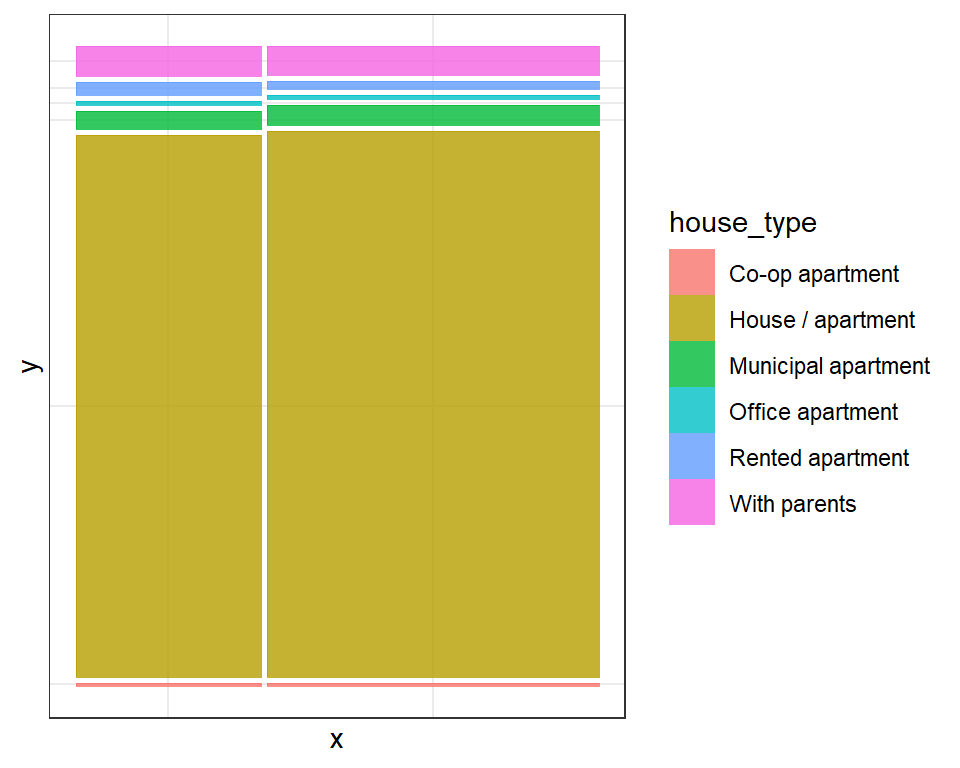

```r
ymd_rec %>%
  filter(!is.na(house_type), !is.na(credit)) %>%
  ggplot()+geom_mosaic(aes(x = product(house_type, credit), fill = house_type))
```

## 4.3 occupation type

accountants, cleaning staff, cooking staff, core staff(정규직), drivers, high skill tech staff, HR staff, IT staff, Laborers, Low-skill Laborers, managers, medicine staff

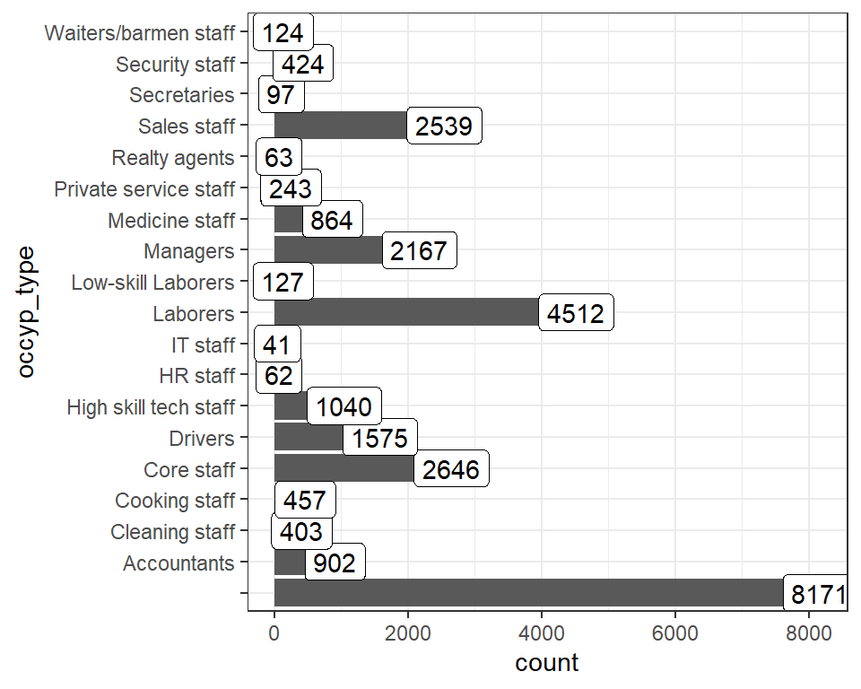

```r
ymd_rec %>%
  ggplot(aes(x = occyp_type)) + geom_bar() +
  geom_label(stat = 'count', aes(label = ..count..))+
  coord_flip()
```

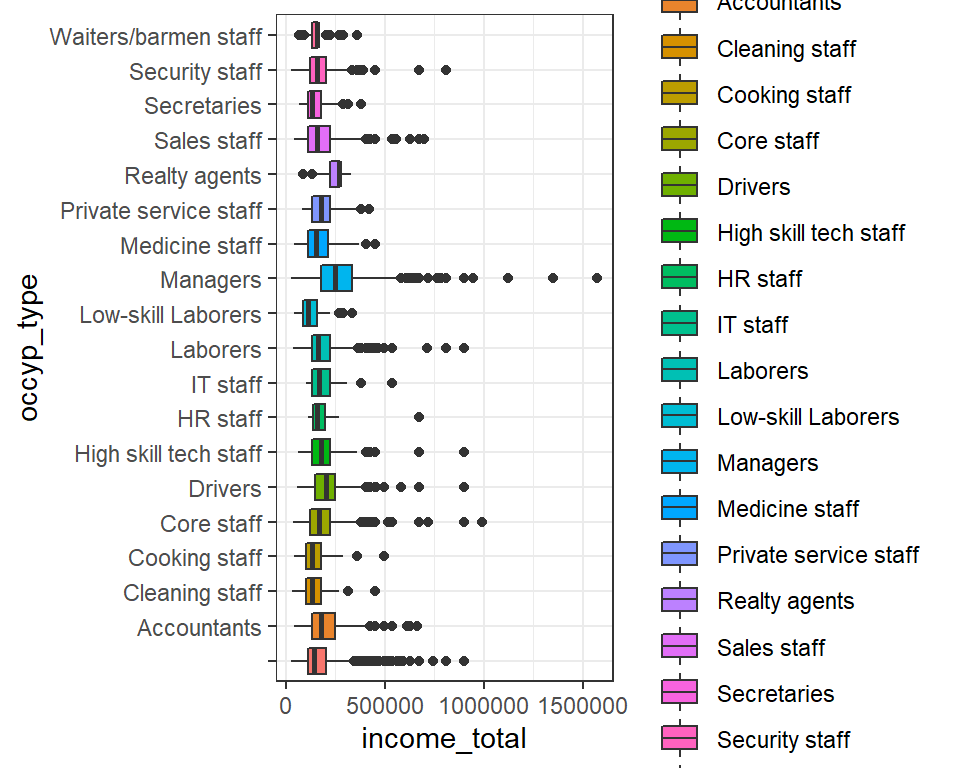

```r
ymd_rec %>%
  filter(!is.na(occyp_type), !is.na(credit)) %>%
  ggplot(aes(x = occyp_type, y = income_total, fill = occyp_type)) +
  geom_boxplot() +
  coord_flip()
```

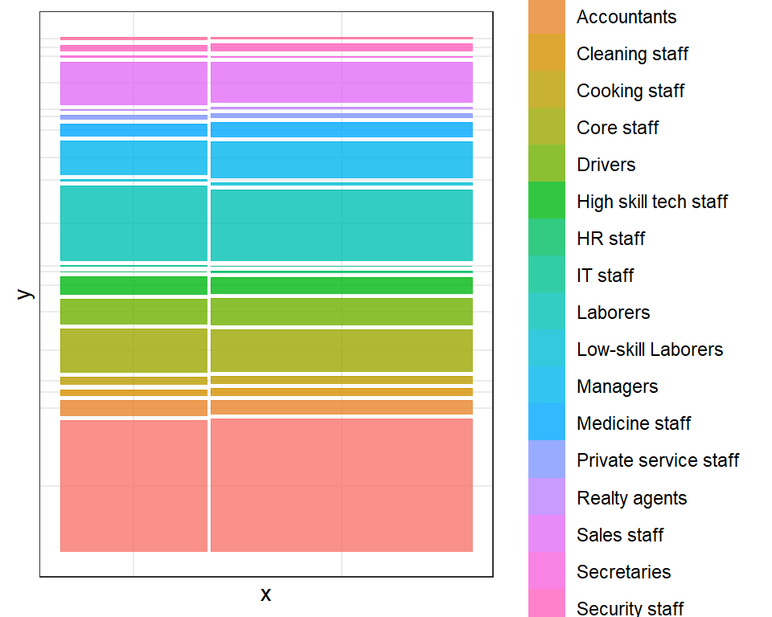

```r
ymd_rec %>%
  filter(!is.na(occyp_type), !is.na(credit)) %>%
  ggplot()+geom_mosaic(aes(x = product(occyp_type, credit), fill =occyp_type))
```

```r
cols <- dat %>%
    select_if(is.factor) %>%
    colnames()
cols
```

```
##  [1] "gender"      "car"         "reality"     "income_type" "edu_type"
##  [6] "family_type" "house_type"  "flag_mobil"  "work_phone"  "phone"
## [11] "email"       "occyp_type"  "credit"
```

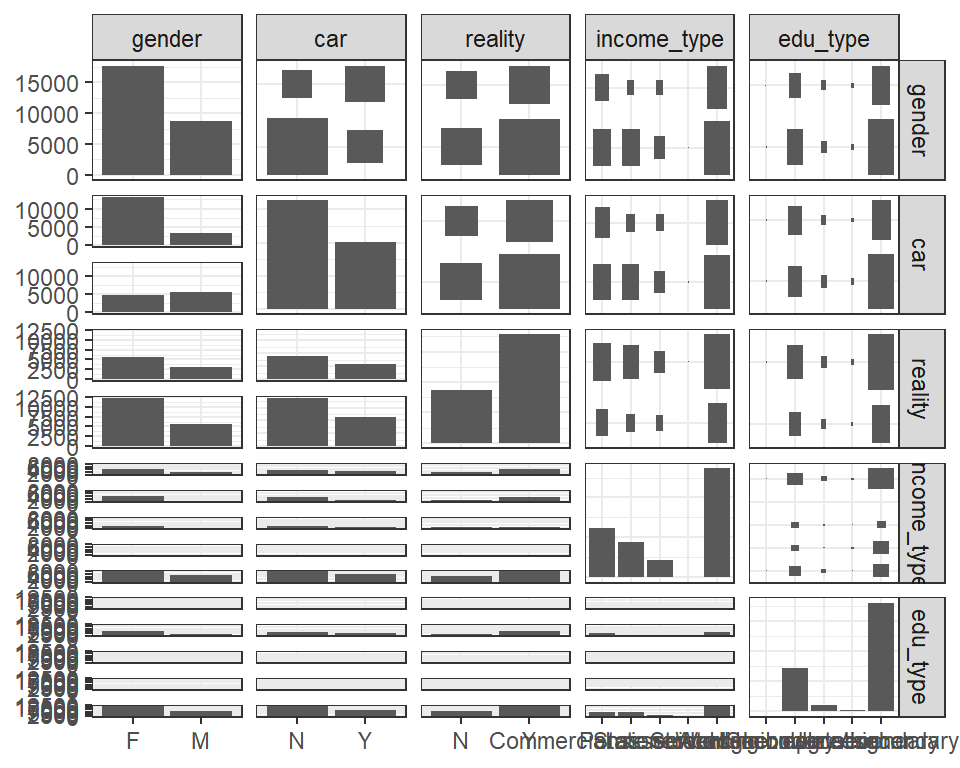

```r
ggpairs(dat, cols[1:5])
```

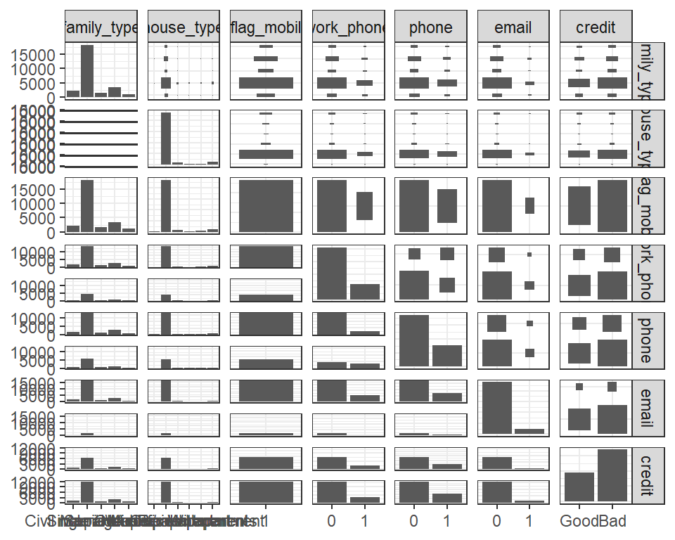

```r
ggpairs(dat, cols[c(6:11, 13)])
```

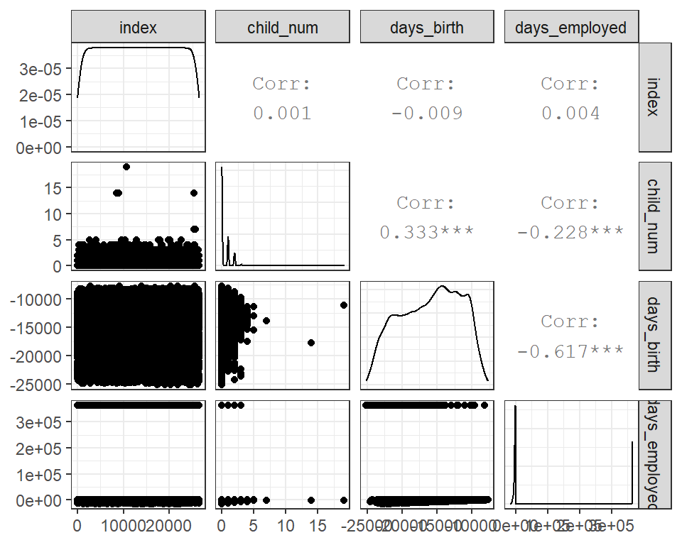

```r
dat %>%
    select_if(is.integer) %>%
    ggpairs()
```

# 5 Data preprocessing(데이터 전처리)

# 6 Recipes

**step_cut : cut 값에 따라 연속형 변수를 이산형 변수로 변환**

- breaks : 연속형 변수의 경계값 지정

```r
dat2 <- dat %>%
    recipe(credit~.) %>%
    step_rm(flag_mobil, index) %>%
    step_mutate(
              days_birth = days_birth + 25152, # 출생일
              days_employed = days_employed + 15713, # 업무 시작일
              begin_month = begin_month + 60) %>%
    step_mutate(
              month_birth = round(days_birth/30),
              month_employed = round(days_employed/30)) %>%
    step_mutate(
              disc_employed = month_employed) %>%

    step_cut(disc_employed, breaks = c(407, 458, 491, 523, 12699)) %>%

    step_other(income_type, occyp_type, house_type, threshold = 0.1, other = 'infreq_combined') %>%
    #step_impute_bag(occyp_type, impute_with = imp_vars(car, reality, income_total, income_type, edu_type, house_type, family_type, family_size),  trees = 100) %>%
    step_normalize(all_numeric(), -all_outcomes()) %>%
    step_rm(days_birth, days_employed, begin_month, month_employed) %>%
    prep() %>%
    juice()
```

# 7 Data split(데이터 분할)

```r
library(rsample)
splits <- initial_split(dat2, prop = 0.7, strata = credit)
train <- training(splits)
test <- testing(splits)
```